# Coursework Report

*N* removed NAs: 3

*N* removed typo: 1

*N* removed <18: 15

*N* total clean: 131

| Group | *N* | *M*<sub>age</sub> | *M*<sub>rating</sub> |
| --- | --- | --- | --- |
| Control | 66 | 20.5 | 5.87 |
| Experim | 65 | 20.5 | 6.63 |

**Main analysis results**

*t*(129) = -5.29, *p* < .001

[interactive chart not shown]

[figure not shown]

[interactive chart not shown]

# Coursework Report

Analysing Data, Spring 2020

# Methods

## Participants

The total initial number of participants in this experiment is 150.

In the end, 131 participants were used as data for our results, (*M*<sub>age</sub> = 20.52, *SD*<sub>age</sub> = 1.74). An age range of 18 - 27.

Table 1 Participant Descriptives table by Condition

| CONDITION | N | % | Mean Age | SD Age |
| --- | --- | --- | --- | --- |
| control | 66 | 50.4 | 20.5 | 1.58 |
| experimental | 65 | 49.6 | 20.5 | 1.90 |

## Design

**Research question:**

Does the association with the colour red increase women’s attraction towards men?

**Conceptual Hypothesis:**

Women perceive men associated with the colour red as more attractive.

**Operationalisation of variables:**

The variables for the experiment were *‘Colour’* and *‘Perceived attractiveness’*.

*‘Colour’* is a categorical variable and has two levels.

- The experimental condition: Red
- The control condition: White/lack of colour

*‘Perceived attractiveness’* was measured through the ratings of 3 questions asked to the participants:

- “How attractive do you think this person is?”
- “How pleasant is this person to look at?”
- “If I were meet the person in this picture face to face, I would think he is attractive”

Ratings were on a 9-point scale.

- A low rating of ‘1’ meant that the model was perceived at not attractive at all while the highest rating of ‘9’ meant that the model was perceived to be extremely attractive.
- The scores were averaged into a composite score.

**Operational hypothesis:**

Men associated with the colour red, on average, score higher ratings for perceived attractiveness compared to men not associated with red (the control group).

The statistical analysis of independent-measures t.test will be conducted.

# Results

## Statistical Analysis

We used an independent-measures *t*-test to analyse the difference in ‘perceived attractiveness’ ratings between the colour conditions. The analysis indicated that the experimental condition received a higher mean rating of perceived attractiveness (*M* = 6.63) compared to the control condition (*M* = 5.87). The difference between means is significant (*M*<sub>diff</sub> = 0.76, 95% CI [-1.04, -0.47], *t* (129) = -5.29, *p* < .001). Both conditions had the same Standard deviation (SD= 0.82).

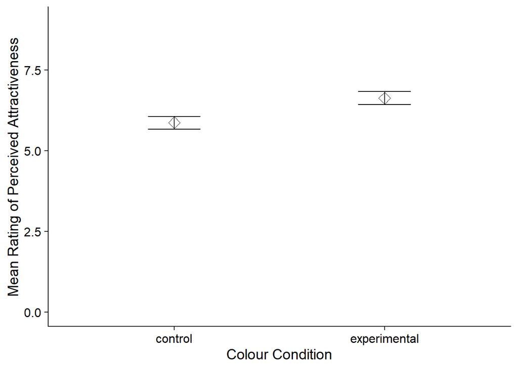

*Plot 1 - illustrating the difference between mean ratings of perceived attractiveness of the two colour conditions.*

## Interpretation

Based on the p-value we received, we reject the Null hypothesis at the .05 significance level. We have sufficient evidence to suggest that the alternative hypothesis should be accepted. The main factor to suggest this is the fact that the p-value is less than .05 ( p < .001) which indicates that the colour red has a significant impact on attractiveness. Furthermore, the difference between the means (*M*<sub>diff</sub> = 0.76) is reasonably significant when taking in the fact that the ratings were measured on a 9-point scale. Additionally, the Confidence Intervals support this conclusion as it indicates that the ratings have little variation and that the mean is a good estimate. The difference between the Confidence Intervals are close to 0 ( *CI*<sub>diff</sub> = 0.57).

Overall, these results suggest that colour has a significant effect on men’s perceived attractiveness. Specifically, it suggests that, on average, a man’s perceived attractiveness by women will increase when associated with the colour red.

# Discussion

## Summary

Our research question; whether men associated with the colour red are more attractive to women, is reinforced by the results of our experiment. This is shown as through the survey, men associated with the colour red are, on average, perceived to be significantly more attractive compared to men not associated with any colour.

## Implications

The original study by Elliot et al. (2010) and our replication study have a similar pattern of results. This is shown as the experimental condition achieves a higher perceived attractiveness rating compared to the control experiment. However, it can be seen that our replication experiment produced results that are even more significant compared to the original study. Our sample size (n=131) is larger compared to the original study (n=21) yet our p-value (p<.001) is more significant than thiers (p= .05). Our replication increases the validity that red association has a positive effect on attractiveness.

The red-attraction effect has been investigated in many different forms, a lot of which show a pattern of results which indicate that the effect is real. To start, there is the Buechner et al. (2015) study which examined the relationship between colours and emotion expression on how they affected the ‘perceived attractiveness’ of the subject. They did a comparison between the colour ‘blue’ and ‘red’ and between the emotion expressions of ‘pride’ and ‘shame’. For female participants, they found that red association increased perceived attractiveness in men displaying ‘pride’ (Buechner et al., 2015).

The red-attraction effect was also studied on men perceiving women which also revealed similar results. The 2013 study by Guéguen and Jacob investigated the effects of colour on the number of contacts received by men on a women’s internet ad. They used photographs that displayed women wearing different coloured clothing (red, black, white, yellow, blue, and green). Out of 2064 participants, they found that women wearing red received significantly more contacts (431 contacts, [20.9%]) compared to the other colours (Guéguen and Jacob, 2013). Additionally, another study that supports the red-attraction effect would the Pazda et al. (2012) study where they examined the effects of the red association on ‘perceived sexual receptivity’. Participants rated women wearing either a red or white shirt on a 9-point scale of ‘Perceived sexual receptivity’ (four face value questions). Results showed that women in red shirts received higher means ratings of perceived sexual receptivity (M = 5.50) compared to women in white shirts (M = 4.30) (Pazda et al., 2012).

The studies above further reaffirm that there is a positive connection between red association and attractiveness.

## Strengths and limitations

These are some limitations of this replication study.

Firstly, this study replicated the first experiment out of the original study’s seven total experiments. Due to that, we are only able to comment on the effects of red-association on ‘perceived attractiveness’. Unlike the original study, we are unable to comment on the effects of red-association for other factors such as perceived likability, agreeableness, extraversion, status or sexual attraction.

Furthermore, some evidence suggests that the effects of red-association may be dependant on the context it is presented. The study by Buechner et al. (2015) implies that not all red-association will achieve the same effect. As mentioned in our implications section, their results show that red increases perceived attractiveness with the emotion expression ‘pride’, however, they also found that red decreased perceived attractiveness in men displaying the emotion expression of ‘shame’. This leads me to believe that the effects of red are contextual and so our results might not be able to be generalized in all situations.

Moreover, as the experiment differentiated the colour conditions by changing the border or the model’s picture, we can only assume our results are relevant to an external red association. We are unable to comment on a non-external red association, such as the redness of one’s skin.

Additionally, the experiment’s results are limited to the comparison of red and our control colour (white). We are unable to comment on the comparison of other colours.

Lastly, the data is limited to the way heterosexual females perceive men. How heterosexual men perceive women or how homosexual participants would perceive their gender of choice when associated with red is not covered.

Nevertheless, we believe that the red attraction effect is real. This belief is supported by the results from our experiment which strongly indicates that red association makes men significantly more attractive and the similar results found in other studies. Even if they found that the relationship between red-association and attractiveness is not extremely strong, there is still a link between them.

## Future Research

There is more to discover regarding the true extent of the red-attraction effect.

One suggestion for future research would be to widen the data scope. One way to do this is to expand the participant range towards the LGBTQ+ community, specifically homosexuals and bisexuals. Most current studies on the red-attraction effect look into how heterosexual women perceive men or vice versa. Additionally, sometimes these studies would include experiments on heterosexual women rating other women with most results indicating that red doesn’t affect attractiveness. This might be because heterosexual women are not attracted to other women. Henceforth, comes our suggestion of testing the red-attraction effect on bisexual and homosexual participants. Not only would it be interesting to see how results would variate compared to heterosexual experiments, but it would also show the effect from a new perspective. For example, if both homosexual men and heterosexual women show significantly high results indicating that red increases men’s attractiveness, the variable of the perceiver’s gender/sexuality are nulled. This would then imply that, generally, men are more attractive when associated with red.

## Conclusion

Overall, the investigation of whether the colour red would affect women’s perceived attractiveness of men was a success. The results show that, in comparison to the control experiment, women perceive men as significantly more attractive when they are associated with red; this coincides with our hypothesis. Additionally, not only did we have a similar pattern of results as the original study, we achieve results more significant than the original. Furthermore, we discussed how other studies such as the ones done by Buechner et al. (2015), Guéguen and Jacob (2013) and Pazda et al. (2012) help increase the validity of the red-attraction effect. Finally, after discussing some limitations of our replication, we decided to develop one of the limitations into the concept of a future study which had the inclusion of bisexual and homosexual participants.

# References

1. Elliot, A., Niesta Kayser, D., Greitemeyer, T., Lichtenfeld, S., Gramzow, R., Maier, M. and Liu, H. (2010). Red, rank, and romance in women viewing men. Journal of Experimental Psychology: General, 139(3), pp.399-417.
2. Buechner, V. L., Maier, M. A., Lichtenfeld, S., & Elliot, A. J. (2015). Emotion expression and color: Their joint influence on perceived attractiveness and social position. Current Psychology, 34(2), 422-433.
3. Guéguen, N., & Jacob, C. (2013). Color and cyber‐attractiveness: red enhances men’s attraction to women’s internet personal ads. Color Research & Application, 38(4), 309-312.
4. Pazda, A. D., Elliot, A. J., & Greitemeyer, T. (2012). Sexy red: Perceived sexual receptivity mediates the red-attraction relation in men viewing woman. Journal of Experimental Social Psychology, 48(3), 787-790.